# COD_20231101_MGK_IBS7048_week10_introduction_to_microbiome_analysis

Minsik Kim

2023-11-01

This analysis pipe noted https://f1000research.com/articles/5-1492.

# Roading the data

from previous lecture.. we generated a phyloseq object. it can be saved to hard disk using the below command.

`saveRDS(ps, "phyloseq_example.rds")`

And it can be loaded to a new R session like below!

```r
library(phyloseq)
library(tidyverse)
library(microbiome)
library(vegan)

phyloseq <- readRDS("phyloseq_example.rds")
```

# Phyloseq object

phyloseq is a list - list of multiple objects such as `sample_data`, `otu_table`, `tax_table`, etc.

```r
phyloseq
```

```
## phyloseq-class experiment-level object
## otu_table()   OTU Table:         [ 225 taxa and 19 samples ]
## sample_data() Sample Data:       [ 19 samples by 4 sample variables ]
## tax_table()   Taxonomy Table:    [ 225 taxa by 6 taxonomic ranks ]
## refseq()      DNAStringSet:      [ 225 reference sequences ]
```

using `sample_data()` function, we can extract `sample_data` only from a phyloseq object

```r
sample_data(phyloseq)
```

```
##        Subject Gender Day  When
## F3D0         3      F   0 Early
## F3D1         3      F   1 Early
## F3D141       3      F 141  Late
## F3D142       3      F 142  Late
## F3D143       3      F 143  Late
## F3D144       3      F 144  Late
## F3D145       3      F 145  Late
## F3D146       3      F 146  Late
## F3D147       3      F 147  Late
## F3D148       3      F 148  Late
## F3D149       3      F 149  Late
## F3D150       3      F 150  Late
## F3D2         3      F   2 Early
## F3D3         3      F   3 Early
## F3D5         3      F   5 Early
## F3D6         3      F   6 Early
## F3D7         3      F   7 Early
## F3D8         3      F   8 Early
## F3D9         3      F   9 Early
```

```r
#or

phyloseq %>%sample_data()
```

```
##        Subject Gender Day  When
## F3D0         3      F   0 Early
## F3D1         3      F   1 Early
## F3D141       3      F 141  Late
## F3D142       3      F 142  Late
## F3D143       3      F 143  Late
## F3D144       3      F 144  Late
## F3D145       3      F 145  Late
## F3D146       3      F 146  Late
## F3D147       3      F 147  Late
## F3D148       3      F 148  Late
## F3D149       3      F 149  Late
## F3D150       3      F 150  Late
## F3D2         3      F   2 Early
## F3D3         3      F   3 Early
## F3D5         3      F   5 Early
## F3D6         3      F   6 Early
## F3D7         3      F   7 Early
## F3D8         3      F   8 Early
## F3D9         3      F   9 Early
```

Note that `sample_data` object is different from `data_frame`. However it can be converted into data_frame as below

```r
phyloseq %>% sample_data() %>% data.frame()
```

```
##        Subject Gender Day  When
## F3D0         3      F   0 Early
## F3D1         3      F   1 Early
## F3D141       3      F 141  Late
## F3D142       3      F 142  Late
## F3D143       3      F 143  Late
## F3D144       3      F 144  Late
## F3D145       3      F 145  Late
## F3D146       3      F 146  Late
## F3D147       3      F 147  Late
## F3D148       3      F 148  Late
## F3D149       3      F 149  Late
## F3D150       3      F 150  Late
## F3D2         3      F   2 Early
## F3D3         3      F   3 Early
## F3D5         3      F   5 Early
## F3D6         3      F   6 Early
## F3D7         3      F   7 Early
## F3D8         3      F   8 Early
## F3D9         3      F   9 Early
```

This is dataframe. You can manipulate it as you want.

# OTU table

`otu_table` object can be pulled out using `otu_table()` function. It is about the abundance (read counts) of each taxa, by sample

```r
otu_table(phyloseq)
```

```
## OTU Table:          [225 taxa and 19 samples]
##                      taxa are columns
##        ASV1 ASV2 ASV3 ASV4 ASV5 ASV6 ASV7 ASV8 ASV9 ASV10 ASV11 ASV12 ASV13
## F3D0    577  345  444  427  154  467  282  183   44   158    16   217    52
## F3D1    404  352  231   68  135   41   96  187   69   106    91    40   127
## F3D141  443  361  340  495  188  325  243  320  166   130   145   145    12
## F3D142  288  303  158  162  178  181  163   89   89    78    41    98    99
## F3D143  230  174  202  230  128  243  152   81  108    68    68   110    43
## F3D144  416  275  301  356  103  353  240   41  158   154   245   145    16
## F3D145  643  488  519  578  301  473  396  125  198   229   292   253    20
## F3D146  325  230  250  389  178  274  212   71  112    88   161   145     4
## F3D147 1489 1213  907 1084  450 1168  853   74  765   267   409   559   143
## F3D148  858  728  575  849  437  871  577  501  404   196   365   430    17
## F3D149  879  778  716  895  415  631  559  510  418   286   429   298    87
## F3D150  314  230  397  467  168  213  231  118  245   149    59    98    64
## F3D2   3479 1575 1167  468  335  115  324 1199  433   614    52    41   324
## F3D3    983  601  464  197  399   25  166  375  307   296   152     0    94
## F3D5    327  270  283  158  151   22  122  205  175   207    53     0    48
## F3D6   1008  671  583  399  473   17  278  259  202   239    39     0   420
## F3D7    644  507  432  311  466   11  195  211  174   270    15     0   115
## F3D8    276  349  348  146  553    0  130  286  112   196    17     0   145
## F3D9    510  420  479  205  592    0  207  437  145   224    26     0   181
##        ASV14 ASV15 ASV16 ASV17 ASV18 ASV19 ASV20 ASV21 ASV22 ASV23 ASV24 ASV25
## F3D0     104    91    78    99    68    67    65    41    44    53    26    70
## F3D1      28   320     0     0    31   108     0    52    14   135     8    69
## F3D141    65    33   103   149    43     6     0    45    85    15    57     0
## F3D142    64    12    52   116    30     6     0     0    34     6    14     0
## F3D143    61     9    40     0    20     0     0    12    65     0     0     0
## F3D144    81    11   113     0    44     5     0    45    17     0    13     0
## F3D145   121    15   123   194   104     5   120    39    13     8    20     0
## F3D146    58    25    35     0    35     0    78    16    77    47    16    19
## F3D147   290    74   303   251   141    41   339   128    79     0   109     9
## F3D148   198    56   269   256   117    55   270   110    94    52   181    12
## F3D149   161    42   177    82   119     4   233   146   262     0   102     8
## F3D150    74    19    29    85    49     5     0    19   143    23    53     6
## F3D2     107   367    17    69   191   399    44    30    17   293    34   333
## F3D3      60    46    24     0   105   342     0   121     0     0    22    43
## F3D5      38    87    35    57    37    17    19    10     0    55    25    57
## F3D6     106    57     0     0    39    74    12    29     0    37    26    66
## F3D7      73    39     0     0    22    39    10    38     0    30    48    13
```

[output cut: 367 more lines]

```
## F3D143      0      0      0      0      0      0      0      0
## F3D144      0      0      0      0      0      0      0      0
## F3D145      0      0      0      0      0      0      0      0
## F3D146      0      0      0      0      0      0      0      0
## F3D147      0      0      0      0      0      0      3      0
## F3D148      0      0      0      0      0      0      0      0
## F3D149      0      0      0      0      0      0      0      0
## F3D150      0      0      0      0      0      0      0      0
## F3D2        0      0      4      4      0      0      0      0
## F3D3        0      0      0      0      4      0      0      2
## F3D5        0      0      0      0      0      0      0      0
## F3D6        0      0      0      0      0      0      0      0
## F3D7        0      0      0      0      0      0      0      0
## F3D8        0      0      0      0      0      0      0      0
## F3D9        0      0      0      0      0      4      0      0
```

# Tax table

`tax_table` object? function `tax_table()`. It contains information about taxonomic rank of the ASVs.

```r
tax_table(phyloseq)
```

```
## Taxonomy Table:     [225 taxa by 6 taxonomic ranks]:
##        Kingdom    Phylum              Class
## ASV1   "Bacteria" "Bacteroidota"      "Bacteroidia"
## ASV2   "Bacteria" "Bacteroidota"      "Bacteroidia"
## ASV3   "Bacteria" "Bacteroidota"      "Bacteroidia"
## ASV4   "Bacteria" "Bacteroidota"      "Bacteroidia"
## ASV5   "Bacteria" "Bacteroidota"      "Bacteroidia"
## ASV6   "Bacteria" "Bacteroidota"      "Bacteroidia"
## ASV7   "Bacteria" "Bacteroidota"      "Bacteroidia"
## ASV8   "Bacteria" "Bacteroidota"      "Bacteroidia"
## ASV9   "Bacteria" "Bacteroidota"      "Bacteroidia"
## ASV10  "Bacteria" "Bacteroidota"      "Bacteroidia"
## ASV11  "Bacteria" "Firmicutes"        "Bacilli"
## ASV12  "Bacteria" "Bacteroidota"      "Bacteroidia"
## ASV13  "Bacteria" "Firmicutes"        "Bacilli"
## ASV14  "Bacteria" "Bacteroidota"      "Bacteroidia"
## ASV15  "Bacteria" "Firmicutes"        "Clostridia"
## ASV16  "Bacteria" "Firmicutes"        "Bacilli"
## ASV17  "Bacteria" "Bacteroidota"      "Bacteroidia"
## ASV18  "Bacteria" "Bacteroidota"      "Bacteroidia"
## ASV19  "Bacteria" "Firmicutes"        "Bacilli"
## ASV20  "Bacteria" "Bacteroidota"      "Bacteroidia"
## ASV21  "Bacteria" "Firmicutes"        "Bacilli"
## ASV22  "Bacteria" "Firmicutes"        "Clostridia"
## ASV23  "Bacteria" "Firmicutes"        "Clostridia"
## ASV24  "Bacteria" "Firmicutes"        "Clostridia"
## ASV25  "Bacteria" "Firmicutes"        "Clostridia"
## ASV26  "Bacteria" "Firmicutes"        "Clostridia"
## ASV27  "Bacteria" "Firmicutes"        "Clostridia"
## ASV28  "Bacteria" "Firmicutes"        "Clostridia"
## ASV29  "Bacteria" "Firmicutes"        "Clostridia"
## ASV30  "Bacteria" "Firmicutes"        "Clostridia"
## ASV31  "Bacteria" "Firmicutes"        "Clostridia"
## ASV32  "Bacteria" "Firmicutes"        "Clostridia"
## ASV33  "Bacteria" "Firmicutes"        "Clostridia"
## ASV34  "Bacteria" "Firmicutes"        "Bacilli"
## ASV35  "Bacteria" "Firmicutes"        "Clostridia"
## ASV36  "Bacteria" "Firmicutes"        "Clostridia"
## ASV37  "Bacteria" "Firmicutes"        "Clostridia"
## ASV38  "Bacteria" "Firmicutes"        "Clostridia"
```

[output cut: 850 more lines]

```
## ASV211 "Streptococcus"
## ASV212 "Anaerotruncus"
## ASV213 "Intestinimonas"
## ASV214 "Intestinimonas"
## ASV215 "Streptococcus"
## ASV216 "[Eubacterium] xylanophilum group"
## ASV217 NA
## ASV218 NA
## ASV219 NA
## ASV220 "GCA-900066575"
## ASV221 NA
## ASV222 NA
## ASV223 NA
## ASV224 "Coriobacteriaceae UCG-002"
## ASV225 NA
```

# Basics of phyloseq

The below functions will enable accessing the object within the phyloseq.

```r
sample_names(phyloseq)
```

```
##  [1] "F3D0"   "F3D1"   "F3D141" "F3D142" "F3D143" "F3D144" "F3D145" "F3D146"
##  [9] "F3D147" "F3D148" "F3D149" "F3D150" "F3D2"   "F3D3"   "F3D5"   "F3D6"
## [17] "F3D7"   "F3D8"   "F3D9"
```

```r
taxa_names(phyloseq)
```

```
##   [1] "ASV1"   "ASV2"   "ASV3"   "ASV4"   "ASV5"   "ASV6"   "ASV7"   "ASV8"
##   [9] "ASV9"   "ASV10"  "ASV11"  "ASV12"  "ASV13"  "ASV14"  "ASV15"  "ASV16"
##  [17] "ASV17"  "ASV18"  "ASV19"  "ASV20"  "ASV21"  "ASV22"  "ASV23"  "ASV24"
##  [25] "ASV25"  "ASV26"  "ASV27"  "ASV28"  "ASV29"  "ASV30"  "ASV31"  "ASV32"
##  [33] "ASV33"  "ASV34"  "ASV35"  "ASV36"  "ASV37"  "ASV38"  "ASV39"  "ASV40"
##  [41] "ASV41"  "ASV42"  "ASV43"  "ASV44"  "ASV45"  "ASV46"  "ASV47"  "ASV48"
##  [49] "ASV49"  "ASV50"  "ASV51"  "ASV52"  "ASV53"  "ASV54"  "ASV55"  "ASV56"
##  [57] "ASV57"  "ASV58"  "ASV59"  "ASV60"  "ASV61"  "ASV62"  "ASV63"  "ASV64"
##  [65] "ASV65"  "ASV66"  "ASV67"  "ASV68"  "ASV69"  "ASV70"  "ASV71"  "ASV72"
##  [73] "ASV73"  "ASV74"  "ASV75"  "ASV76"  "ASV77"  "ASV78"  "ASV79"  "ASV80"
##  [81] "ASV81"  "ASV82"  "ASV83"  "ASV84"  "ASV85"  "ASV86"  "ASV87"  "ASV88"
##  [89] "ASV89"  "ASV90"  "ASV91"  "ASV92"  "ASV93"  "ASV94"  "ASV95"  "ASV96"
##  [97] "ASV97"  "ASV98"  "ASV99"  "ASV100" "ASV101" "ASV102" "ASV103" "ASV104"
## [105] "ASV105" "ASV106" "ASV107" "ASV108" "ASV109" "ASV110" "ASV111" "ASV112"
## [113] "ASV113" "ASV114" "ASV115" "ASV116" "ASV117" "ASV118" "ASV119" "ASV120"
## [121] "ASV121" "ASV122" "ASV123" "ASV124" "ASV125" "ASV126" "ASV127" "ASV128"
## [129] "ASV129" "ASV130" "ASV131" "ASV132" "ASV133" "ASV134" "ASV135" "ASV136"
## [137] "ASV137" "ASV138" "ASV139" "ASV140" "ASV141" "ASV142" "ASV143" "ASV144"
## [145] "ASV145" "ASV146" "ASV147" "ASV148" "ASV149" "ASV150" "ASV151" "ASV152"
## [153] "ASV153" "ASV154" "ASV155" "ASV156" "ASV157" "ASV158" "ASV159" "ASV160"
## [161] "ASV161" "ASV162" "ASV163" "ASV164" "ASV165" "ASV166" "ASV167" "ASV168"
## [169] "ASV169" "ASV170" "ASV171" "ASV172" "ASV173" "ASV174" "ASV175" "ASV176"
## [177] "ASV177" "ASV178" "ASV179" "ASV180" "ASV181" "ASV182" "ASV183" "ASV184"
## [185] "ASV185" "ASV186" "ASV187" "ASV188" "ASV189" "ASV190" "ASV191" "ASV192"
## [193] "ASV193" "ASV194" "ASV195" "ASV196" "ASV197" "ASV198" "ASV199" "ASV200"
## [201] "ASV201" "ASV202" "ASV203" "ASV204" "ASV205" "ASV206" "ASV207" "ASV208"
## [209] "ASV209" "ASV210" "ASV211" "ASV212" "ASV213" "ASV214" "ASV215" "ASV216"
## [217] "ASV217" "ASV218" "ASV219" "ASV220" "ASV221" "ASV222" "ASV223" "ASV224"
## [225] "ASV225"
```

```r
rank_names(phyloseq)
```

```
## [1] "Kingdom" "Phylum"  "Class"   "Order"   "Family"  "Genus"
```

```r
rank_names(phyloseq)
```

```
## [1] "Kingdom" "Phylum"  "Class"   "Order"   "Family"  "Genus"
```

# Summary of phyloseq object

Create table, number of features for each phyla

```r
table(tax_table(phyloseq)[, "Phylum"], exclude = NULL)
```

```
##
##  Actinobacteriota      Bacteroidota  Campylobacterota     Cyanobacteria
##                 6                19                 1                 3
##      Deinococcota        Firmicutes   Patescibacteria    Proteobacteria
##                 1               185                 2                 7
## Verrucomicrobiota
##                 1
```

We can see that most of taxa were from Firmicutes phylum.

Making a table of prevalence will show you this.

```r
# Compute prevalence of each feature, store as data.frame
prevdf = apply(X = otu_table(phyloseq),
                 MARGIN = ifelse(taxa_are_rows(phyloseq), yes = 1, no = 2),
                 FUN = function(x){sum(x > 0)})
# Add taxonomy and total read counts to this data.frame
prevdf = data.frame(Prevalence = prevdf,
                      TotalAbundance = taxa_sums(phyloseq),
                      tax_table(phyloseq))


plyr::ddply(prevdf, "Phylum", function(df1){cbind(mean(df1$Prevalence),sum(df1$Prevalence))}) %>%
        rename(avg_reads = "1", prevalence = "2")
```

```
##              Phylum avg_reads prevalence
## 1  Actinobacteriota  4.666667         28
## 2      Bacteroidota 13.842105        263
## 3  Campylobacterota  0.000000          0
## 4     Cyanobacteria  1.666667          5
## 5      Deinococcota  1.000000          1
## 6        Firmicutes  6.648649       1230
## 7   Patescibacteria  7.500000         15
## 8    Proteobacteria  3.714286         26
## 9 Verrucomicrobiota  2.000000          2
```

You ca do the same thing for other taxonomic ranks as well.

```r
plyr::ddply(prevdf, "Family", function(df1){cbind(mean(df1$Prevalence),sum(df1$Prevalence))}) %>%
        rename(avg_reads = "1", prevalence = "2")
```

```
##                                   Family  avg_reads prevalence
## 1  [Eubacterium] coprostanoligenes group  3.0000000          3
## 2                     Acholeplasmataceae 10.0000000         10
## 3                       Actinomycetaceae  0.0000000          0
## 4                        Akkermansiaceae  2.0000000          2
## 5                       Anaerovoracaceae 13.5000000         27
## 6                           Atopobiaceae  1.0000000          1
## 7                            Bacillaceae  0.0000000          0
## 8                         Bacteroidaceae  9.5000000         19
## 9                     Bifidobacteriaceae 13.0000000         13
## 10                     Butyricicoccaceae  2.0000000          2
## 11                   Christensenellaceae  9.0000000          9
## 12                        Clostridiaceae  4.3333333         13
## 13                        Deinococcaceae  1.0000000          1
## 14                       Eggerthellaceae  4.6666667         14
```

[output cut: 23 more lines]

# Pevalence filtering

In many literature, they filter taxa that is having low-prevalence (to remove sequencing errors). *It is not neccessary, but to do that you can use the below code*

First, we can visualize the prevalence of those taxa in each phylum as below.

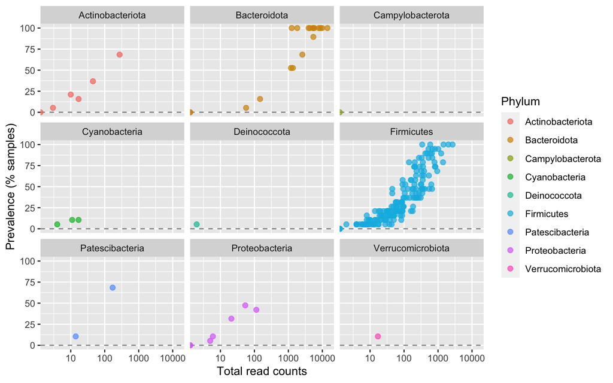

```r
# Subset to the remaining phyla
prevdf1 = subset(prevdf, Phylum %in% get_taxa_unique(phyloseq, "Phylum"))

ggplot(prevdf1, aes(TotalAbundance, Prevalence / nsamples(phyloseq) * 100,color=Phylum)) +
  # Include a guess for parameter
        geom_hline(yintercept = 0.05, alpha = 0.5, linetype = 2) +
        geom_point(size = 2, alpha = 0.7) +
        scale_x_log10() +
        xlab("Total read counts") +
        ylab("Prevalence (% samples)") +
        facet_wrap(~Phylum)
```

You can see some of taxa were low-prevalent.

```r
prevalenceThreshold = 0.1 * nsamples(phyloseq)
prevalenceThreshold
```

```
## [1] 1.9
```

```r
taxa_to_keep = rownames(prevdf1)[(prevdf1$Prevalence >= prevalenceThreshold)]
phyloseq_filtered = prune_taxa(taxa_to_keep, phyloseq)
```

We filtered 48 taxa, that they were having prevalecne lower than 1.9!

Now, let’s see how many genus do we have.

```r
length(get_taxa_unique(phyloseq_filtered, taxonomic.rank = "Genus"))
```

```
## [1] 40
```

There are 40 genuses, and

```r
tax_table(phyloseq_filtered) %>%
        data.frame %>%
        .$Genus %>%
        table(useNA = "always")
```

```
## .
##      [Eubacterium] nodatum group [Eubacterium] xylanophilum group
##                                1                                1
##                               A2                    Acetatifactor
##                                5                                3
##                      Akkermansia                        Alistipes
##                                1                                1
##                     Anaeroplasma                    Anaerotruncus
##                                1                                1
##                           ASF356                      Bacteroides
##                                2                                1
##                  Bifidobacterium                   Butyricicoccus
##                                1                                1
##           Candidatus Arthromitus         Candidatus Saccharimonas
##                                1                                2
##          Candidatus Stoquefichus      Clostridium sensu stricto 1
##                                1                                2
##                 Colidextribacter                    Enterorhabdus
##                                4                                2
##             Escherichia-Shigella              Family XIII UCG-001
##                                1                                1
##                    GCA-900066575                            HT002
##                                4                                1
##                   Incertae Sedis                   Intestinimonas
##                                2                                1
##                Lachnoclostridium     Lachnospiraceae FCS020 group
##                                5                                2
##    Lachnospiraceae NK4A136 group          Lachnospiraceae UCG-001
##                               20                                4
##          Lachnospiraceae UCG-004          Lachnospiraceae UCG-006
##                                1                                2
##                    Lactobacillus                Ligilactobacillus
##                                1                                1
##                        Neisseria                    Oscillibacter
##                                1                                3
##                      Pseudomonas                        Roseburia
##                                1                               11
##                    Streptococcus                     Turicibacter
##                                1                                1
##                       Tyzzerella                             <NA>
##                                1                               81
```

# Lets remove taxa without Genus assignment

```r
phyloseq_genus = tax_glom(phyloseq_filtered, "Genus", NArm = TRUE)
```

# Relative abundacne

Now, we can look at their abundance barplot.

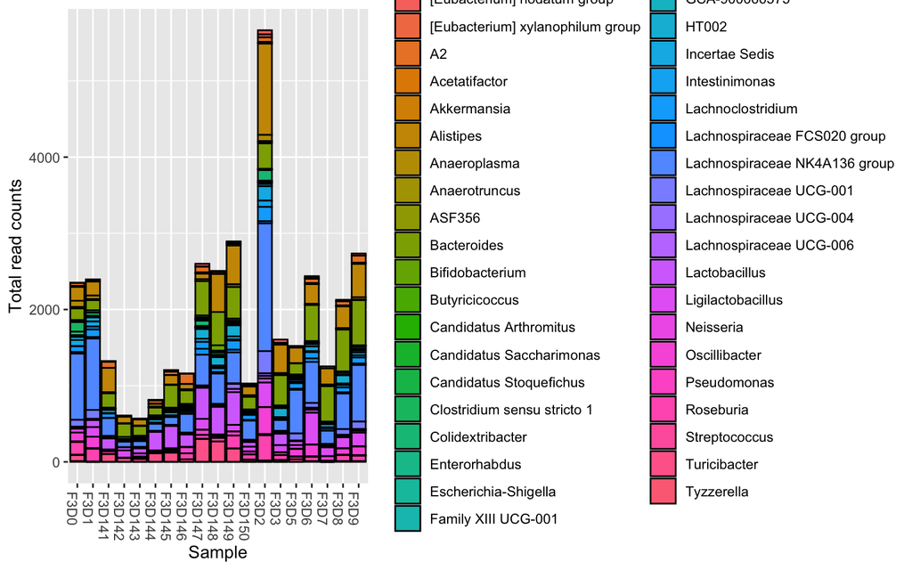

```r
plot_bar(phyloseq_genus, fill = "Genus") +
        ylab("Total read counts")
```

Alternatively,

```r
# Create a df with all `Top 10 Genus` and flag the top 20
top <- phyloseq_genus %>% taxa_sums %>% sort(decreasing=TRUE) %>%
        names %>% as.data.frame(labels=TRUE) %>% rename(`Top 10 Genus`=".") %>%
        mutate(`Top 10 Genus`=as.factor(case_when( #create agg`Top 10 Genus` variable
                row_number()<=10~`Top 10 Genus`,row_number()>10~'Other'
                )
                )
               )
top
```

```
##    Top 10 Genus
## 1         ASV15
## 2          ASV5
## 3          ASV8
## 4         ASV11
## 5         ASV13
## 6         ASV26
## 7         ASV43
## 8         ASV16
## 9         ASV44
## 10        ASV21
## 11        Other
## 12        Other
## 13        Other
## 14        Other
```

[output cut: 25 more lines]

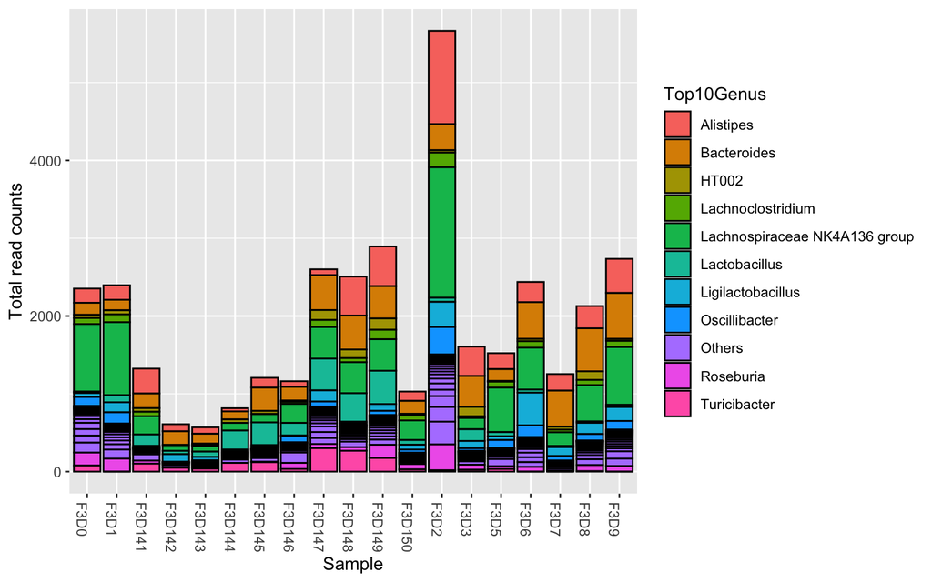

```r
top_tax_table <- tax_table(phyloseq_genus) %>% data.frame() %>%
        mutate(ASV = rownames(.),
                `Top10Genus` = case_when(ASV %in% top$`Top 10 Genus` ~ Genus,
                                          .default = "Others")
        )

phyloseq_genus_top_10 <- merge_phyloseq(tax_table(as.matrix(top_tax_table)),
                                        otu_table(phyloseq_genus),
                                        sample_data(phyloseq_genus))


plot_bar(phyloseq_genus_top_10, fill = "Top10Genus") +
        ylab("Total read counts")
```

As I thaught in the lecture, the sequencing dataset’s total read counts does not mean something. It need to be noralized to `relative abundance` unless its sequencing procedure is contianing internal standards (i.e., spiek-ins) or other data such as ddPCR/PCR abundance estimates.

```r
phyloseq_rel <- transform_sample_counts(phyloseq_genus_top_10, function(x){x/sum(x)})
```

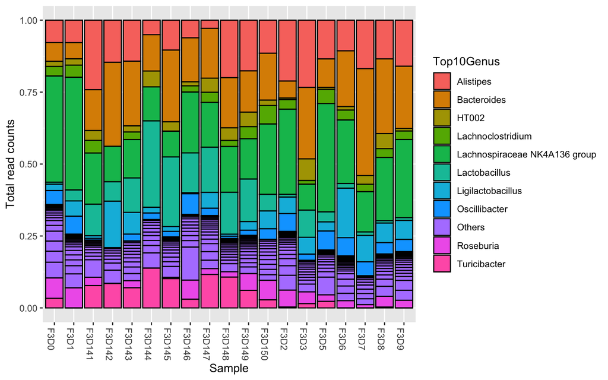

```r
plot_bar(phyloseq_rel, fill = "Top10Genus") +
        ylab("Total read counts")
```

We had one variable! Can we facet the plot by its sample data.

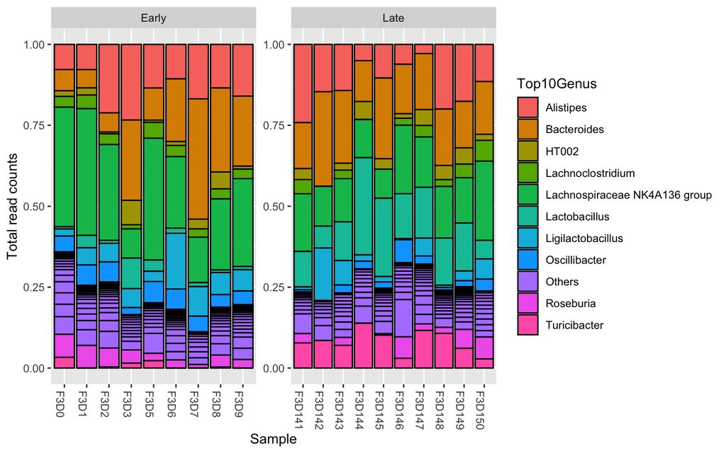

```r
plot_bar(phyloseq_rel, fill = "Top10Genus") +
        ylab("Total read counts") +
        facet_wrap(~When, scales = "free")
```

With more functions, we can make the plot prettier

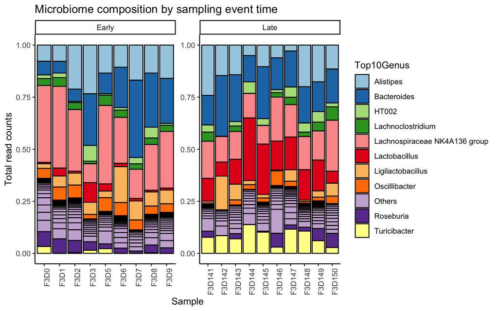

```r
plot_bar(phyloseq_rel, fill = "Top10Genus") +
        ylab("Total read counts") +
        theme_classic() +
        theme(axis.text.x = element_text(angle = 90)) +
        scale_fill_brewer(type = "qual", palette = 3) +
        facet_wrap(~When, scales = "free") +
        ggtitle("Microbiome composition by sampling event time")
```

Can you see the difference?

Of course ifyou not. We need to calculate some *simple matrices* so that a number can represent the data at once.

```r
microbiome::alpha(phyloseq_rel)
```

```
##        observed chao1 diversity_inverse_simpson diversity_gini_simpson
## F3D0         27    27                  6.055101              0.8348500
## F3D1         27    27                  5.473731              0.8173092
## F3D141       20    20                  7.311927              0.8632371
## F3D142       14    14                  6.118230              0.8365540
## F3D143       20    20                  8.458811              0.8817801
## F3D144       18    18                  6.641652              0.8494351
## F3D145       24    24                  6.477691              0.8456240
## F3D146       22    22                  8.536879              0.8828612
## F3D147       27    27                  9.572472              0.8955338
## F3D148       27    27                  7.532499              0.8672419
## F3D149       27    27                  9.309459              0.8925824
## F3D150       21    21                  8.317748              0.8797752
## F3D2         33    33                  6.532057              0.8469089
## F3D3         21    21                  6.827747              0.8535388
## F3D5         24    24                  5.415914              0.8153590
## F3D6         27    27                  7.339601              0.8637528
## F3D7         19    19                  4.996238              0.7998494
## F3D8         27    27                  6.762416              0.8521238
## F3D9         26    26                  6.356050              0.8426696
##        diversity_shannon diversity_coverage evenness_camargo evenness_pielou
## F3D0            2.443989                  3        0.3421164       0.7415383
## F3D1            2.339922                  3        0.3130526       0.7099630
## F3D141          2.292807                  3        0.3554003       0.7653576
## F3D142          2.063371                  3        0.4024161       0.7818592
## F3D143          2.453088                  3        0.4195079       0.8188608
## F3D144          2.266895                  3        0.3772324       0.7842918
## F3D145          2.255152                  3        0.2924613       0.7096016
## F3D146          2.444567                  3        0.3695040       0.7908553
## F3D147          2.605667                  4        0.3682202       0.7905935
## F3D148          2.340649                  3        0.2895153       0.7101834
## F3D149          2.552235                  4        0.3494331       0.7743815
## F3D150          2.489153                  3        0.4144107       0.8175841
## F3D2            2.388560                  2        0.2603065       0.6831275
## F3D3            2.306098                  3        0.3437111       0.7574579
## F3D5            2.239871                  2        0.2964301       0.7047932
## F3D6            2.376133                  3        0.2931972       0.7209500
## F3D7            2.051146                  2        0.3015193       0.6966169
## F3D8            2.341600                  3        0.2864801       0.7104720
## F3D9            2.298808                  3        0.2858810       0.7055678
```

[output cut: 65 more lines]

```
## F3D143          0.000000000           0.000000000
## F3D144          0.000000000           0.002453988
## F3D145          0.001658375           0.003316750
## F3D146          0.000000000           0.000000000
## F3D147          0.004998078           0.003460208
## F3D148          0.008376546           0.002792182
## F3D149          0.000000000           0.000000000
## F3D150          0.000000000           0.000000000
## F3D2            0.009885260           0.003353928
## F3D3            0.000000000           0.000000000
## F3D5            0.001314060           0.002628121
## F3D6            0.001640689           0.002871206
## F3D7            0.003189793           0.001594896
## F3D8            0.004229323           0.002819549
## F3D9            0.000000000           0.006946984
```

Let’s add the diversity indices to original sample_data().

```r
sample_data_with_alpha <-
        phyloseq_rel %>%
        sample_data() %>%
        merge(., #Merge function will do the same thing as vloopup at excel
              microbiome::alpha(phyloseq_rel),
              by = 0) %>%
        column_to_rownames("Row.names") %>%
        sample_data

sample_data(phyloseq_rel) <- sample_data_with_alpha
```

# Alpha diversity boxplots

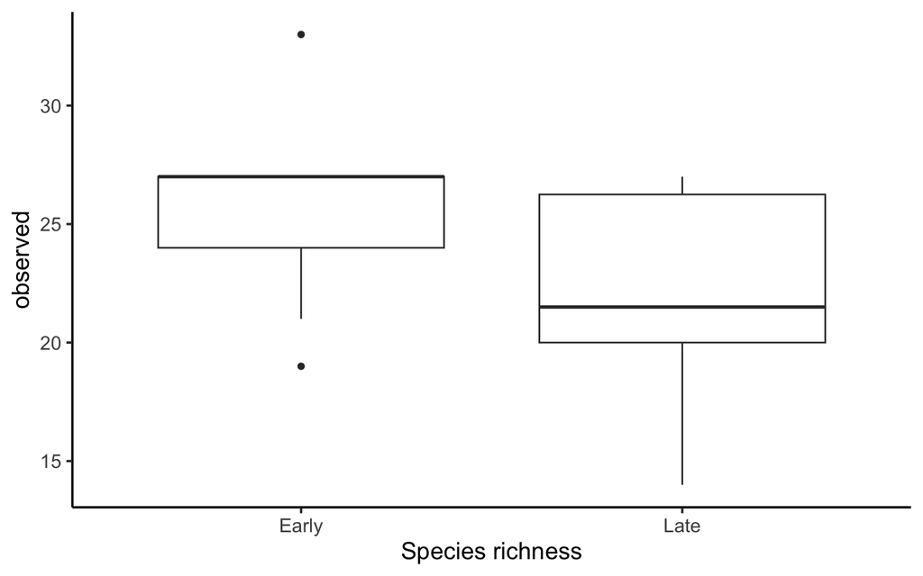

```r
sample_data_with_alpha %>%
        ggplot(aes(x = When, y = observed)) +
        geom_boxplot() +
        xlab("Species richness") +
        theme_classic(base_size = 15)
```

As you can see, the alpha-diversity (species richenss) seemd to have different values.

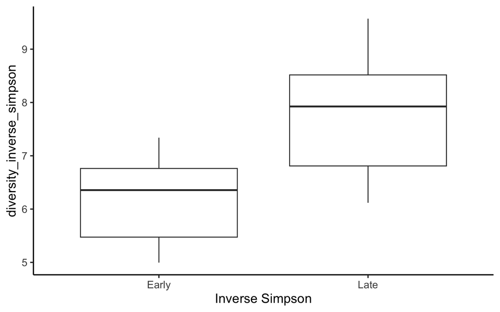

```r
sample_data_with_alpha %>%
        ggplot(aes(x = When, y = diversity_inverse_simpson)) +
        geom_boxplot() +
        xlab("Inverse Simpson") +
        theme_classic(base_size = 15)
```

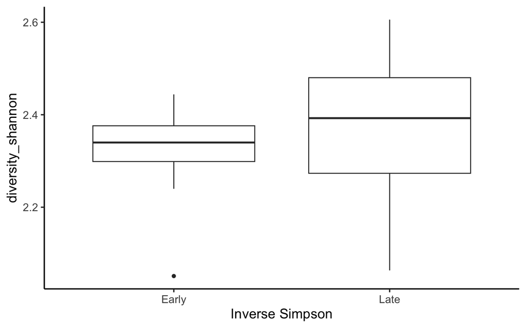

```r
sample_data_with_alpha %>%
        ggplot(aes(x = When, y = diversity_shannon)) +
        geom_boxplot() +
        xlab("Inverse Simpson") +
        theme_classic(base_size = 15)
```

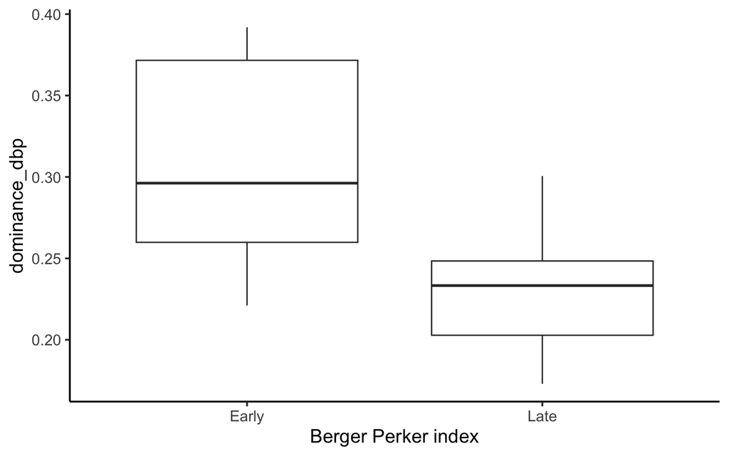

```r
sample_data_with_alpha %>%
        ggplot(aes(x = When, y = dominance_dbp)) +
        geom_boxplot() +
        xlab("Berger Perker index") +
        theme_classic(base_size = 15)
```

It seems like there are multiple different changes in alpha diversity!

# How about Beta?

Distances between two samples, can be calculated in many ways.

Famous calculations, can be done with `dist()` function

## Beta diversity calculation

### Bray-Curtis distnaces

```r
phyloseq::distance(phyloseq_rel, method = "bray")
```

```
##             F3D0      F3D1    F3D141    F3D142    F3D143    F3D144    F3D145
## F3D1   0.1617363
## F3D141 0.5016585 0.5101768
## F3D142 0.6117886 0.6132388 0.4003778
## F3D143 0.5025906 0.4843155 0.2466802 0.2161918
## F3D144 0.5916932 0.6137586 0.3695281 0.4525049 0.3579027
## F3D145 0.5894426 0.6171674 0.3545452 0.3277006 0.2543390 0.2207622
## F3D146 0.3941444 0.3897431 0.2996539 0.5110689 0.3205143 0.3773640 0.3897923
## F3D147 0.4830239 0.4819109 0.3182267 0.3897137 0.2463592 0.2606685 0.2771466
## F3D148 0.5199403 0.5347185 0.1700583 0.3293065 0.2127113 0.3141956 0.2614451
## F3D149 0.4668561 0.4590682 0.1834836 0.3871171 0.1870551 0.3349880 0.3229820
## F3D150 0.3376365 0.3128712 0.2943821 0.3977749 0.2441448 0.4685769 0.4318809
## F3D2   0.2485925 0.1876468 0.4150413 0.5465322 0.4312941 0.6483347 0.6189519
## F3D3   0.5845165 0.5330330 0.2917073 0.3474962 0.2490386 0.4864710 0.3310007
## F3D5   0.2351819 0.1661146 0.4207296 0.5312526 0.4222672 0.5807099 0.5533829
## F3D6   0.3858591 0.3360574 0.4173695 0.3627506 0.3334254 0.5691067 0.4764460
## F3D7   0.5255556 0.4740683 0.4338552 0.3032778 0.2921884 0.5811117 0.4332722
## F3D8   0.3797454 0.3408312 0.3741496 0.3606538 0.2713762 0.5329299 0.3964817
## F3D9   0.3325041 0.3080068 0.3687184 0.3974766 0.2851277 0.5693409 0.4426190
##           F3D146    F3D147    F3D148    F3D149    F3D150      F3D2      F3D3
## F3D1
## F3D141
## F3D142
## F3D143
## F3D144
## F3D145
## F3D146
## F3D147 0.3151208
## F3D148 0.3314454 0.2183458
## F3D149 0.2910877 0.2485167 0.1617427
## F3D150 0.2557577 0.3357466 0.3289220 0.2506966
## F3D2   0.4153860 0.5068482 0.4497999 0.3993305 0.3114090
## F3D3   0.4607796 0.3852846 0.2930264 0.2850502 0.3663794 0.4269560
## F3D5   0.3899367 0.4731186 0.4397820 0.3949387 0.2940794 0.2228297 0.4843115
## F3D6   0.3556843 0.3768053 0.4151169 0.4033297 0.2518820 0.3046959 0.4094132
## F3D7   0.5032612 0.4392937 0.3938427 0.3883225 0.3917516 0.4018519 0.2847218
## F3D8   0.3692703 0.3576776 0.3646637 0.3481337 0.2380601 0.2851322 0.2818033
## F3D9   0.3639325 0.3874616 0.3768846 0.3739463 0.2316304 0.2128126 0.3429557
##             F3D5      F3D6      F3D7      F3D8
## F3D1
## F3D141
## F3D142
## F3D143
## F3D144
## F3D145
## F3D146
## F3D147
## F3D148
## F3D149
## F3D150
## F3D2
## F3D3
## F3D5
## F3D6   0.3113412
## F3D7   0.4349393 0.2977883
## F3D8   0.3159445 0.1844183 0.2157382
## F3D9   0.2594025 0.1775646 0.2520974 0.1174927
```

### Jaccard distnaces

```r
phyloseq::distance(phyloseq_rel, method = "jaccard")
```

```
##             F3D0      F3D1    F3D141    F3D142    F3D143    F3D144    F3D145
## F3D1   0.2784389
## F3D141 0.6681393 0.6756518
## F3D142 0.7591425 0.7602579 0.5718139
## F3D143 0.6689655 0.6525776 0.3957393 0.3555225
## F3D144 0.7434764 0.7606573 0.5396430 0.6230683 0.5271404
## F3D145 0.7416973 0.7632696 0.5234897 0.4936363 0.4055347 0.3616793
## F3D146 0.5654283 0.5608851 0.4611288 0.6764336 0.4854386 0.5479510 0.5609360
## F3D147 0.6514040 0.6503912 0.4828103 0.5608547 0.3953262 0.4135401 0.4340090
## F3D148 0.6841589 0.6968294 0.2906834 0.4954561 0.3508028 0.4781565 0.4145168
## F3D149 0.6365398 0.6292622 0.3100737 0.5581607 0.3151582 0.5018592 0.4882636
## F3D150 0.5048255 0.4766213 0.4548612 0.5691544 0.3924700 0.6381374 0.6032358
## F3D2   0.3981963 0.3159977 0.5866137 0.7067841 0.6026632 0.7866542 0.7646328
## F3D3   0.7377853 0.6953966 0.4516616 0.5157657 0.3987685 0.6545314 0.4973711
## F3D5   0.3808053 0.2849027 0.5922726 0.6938798 0.5937945 0.7347457 0.7124874
## F3D6   0.5568519 0.5030584 0.5889353 0.5323800 0.5001035 0.7253894 0.6453958
## F3D7   0.6890022 0.6432108 0.6051590 0.4654077 0.4522380 0.7350673 0.6045917
## F3D8   0.5504572 0.5083879 0.5445544 0.5301184 0.4269015 0.6953089 0.5678294
## F3D9   0.4990665 0.4709560 0.5387791 0.5688490 0.4437344 0.7255796 0.6136326
##           F3D146    F3D147    F3D148    F3D149    F3D150      F3D2      F3D3
## F3D1
## F3D141
## F3D142
## F3D143
## F3D144
## F3D145
## F3D146
## F3D147 0.4792271
## F3D148 0.4978731 0.3584299
## F3D149 0.4509186 0.3980991 0.2784484
## F3D150 0.4073361 0.5027100 0.4950207 0.4008912
## F3D2   0.5869579 0.6727263 0.6204993 0.5707451 0.4749228
## F3D3   0.6308681 0.5562533 0.4532411 0.4436406 0.5362777 0.5984150
## F3D5   0.5610855 0.6423361 0.6109008 0.5662453 0.4544998 0.3644493 0.6525739
## F3D6   0.5247303 0.5473618 0.5866892 0.5748182 0.4024054 0.4670757 0.5809697
## F3D7   0.6695592 0.6104295 0.5651179 0.5594126 0.5629620 0.5733158 0.4432427
## F3D8   0.5393680 0.5268963 0.5344375 0.5164677 0.3845695 0.4437399 0.4396982
## F3D9   0.5336518 0.5585186 0.5474455 0.5443391 0.3761363 0.3509406 0.5107476
##             F3D5      F3D6      F3D7      F3D8
## F3D1
## F3D141
## F3D142
## F3D143
## F3D144
## F3D145
## F3D146
## F3D147
## F3D148
## F3D149
## F3D150
## F3D2
## F3D3
## F3D5
## F3D6   0.4748440
## F3D7   0.6062129 0.4589167
## F3D8   0.4801790 0.3114074 0.3549090
## F3D9   0.4119453 0.3015793 0.4026802 0.2102792
```

```r
phyloseq::distance(phyloseq_rel, method = "horn")
```

```
##              F3D0       F3D1     F3D141     F3D142     F3D143     F3D144
## F3D1   0.02293791
## F3D141 0.31440360 0.32879875
## F3D142 0.48435499 0.49063321 0.22965562
## F3D143 0.39431481 0.39675127 0.10886823 0.06834966
## F3D144 0.57294881 0.55785661 0.29741570 0.38456741 0.23887811
## F3D145 0.58013274 0.58069159 0.20912368 0.19266782 0.09784677 0.08300786
## F3D146 0.23906577 0.23853859 0.18773184 0.32672592 0.17323649 0.23148743
## F3D147 0.36985596 0.37663599 0.23652116 0.21405417 0.10501787 0.11887282
## F3D148 0.35924358 0.37731801 0.03466328 0.17842858 0.06106949 0.19431600
## F3D149 0.36038892 0.35842308 0.05220906 0.21809442 0.06146666 0.21125792
## F3D150 0.13571572 0.13691079 0.13414015 0.20773123 0.11417299 0.39649607
## F3D2   0.09459553 0.08556185 0.17873477 0.39289127 0.30500147 0.59927745
## F3D3   0.50596202 0.50248736 0.11856858 0.12317124 0.07612092 0.38793833
## F3D5   0.04150792 0.02677851 0.23119795 0.39710106 0.31155289 0.51947519
## F3D6   0.23380305 0.21172668 0.26161901 0.13709554 0.15405099 0.52430577
## F3D7   0.46502508 0.46760567 0.26550304 0.08257750 0.13189334 0.53899005
## F3D8   0.23643511 0.23980404 0.18028080 0.13046821 0.11186190 0.49510460
## F3D9   0.15209129 0.15297836 0.15318324 0.17465415 0.14584728 0.51012265
##            F3D145     F3D146     F3D147     F3D148     F3D149     F3D150
## F3D1
## F3D141
## F3D142
## F3D143
## F3D144
## F3D145
## F3D146 0.20729215
## F3D147 0.10876672 0.13338698
## F3D148 0.11080695 0.19269561 0.14580677
## F3D149 0.14150629 0.16652800 0.14480426 0.03236356
## F3D150 0.30522564 0.11610818 0.17803641 0.15218762 0.12308623
## F3D2   0.54568199 0.27314423 0.42597371 0.26335625 0.24730294 0.11903613
## F3D3   0.17921961 0.30781849 0.28385278 0.10244433 0.10312381 0.20931376
## F3D5   0.49294253 0.22448788 0.34181816 0.27646047 0.28861883 0.10604831
## F3D6   0.38607726 0.23770124 0.25914410 0.27947942 0.25398092 0.08419785
## F3D7   0.26775087 0.34050361 0.32513626 0.24286750 0.27320874 0.21409587
## F3D8   0.29833330 0.19743583 0.24126987 0.18893736 0.19448643 0.07131076
## F3D9   0.34872402 0.18145326 0.27541947 0.19011435 0.20242412 0.05202218
##              F3D2       F3D3       F3D5       F3D6       F3D7       F3D8
## F3D1
## F3D141
## F3D142
## F3D143
## F3D144
## F3D145
## F3D146
## F3D147
## F3D148
## F3D149
## F3D150
## F3D2
## F3D3   0.32557820
## F3D5   0.05466903 0.39499616
## F3D6   0.17712478 0.22782074 0.17829804
## F3D7   0.37047276 0.09981207 0.36452275 0.15149821
## F3D8   0.18875677 0.12889512 0.17431440 0.06735324 0.06707938
## F3D9   0.10059747 0.18152390 0.09097087 0.06272670 0.12550318 0.02461637
```

These distances, cannot be displayed in single pannel as they are having multiple dimensions. Then need to be ordinated (scaled-down to 2 dimension).

## Ordination

### Principal Coordinates Analysis with Bray-Curtis dist

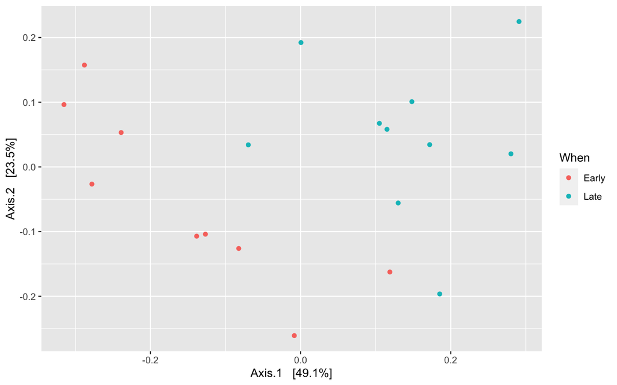

```r
plot_ordination(physeq = phyloseq_rel,
                ordination = ordinate(phyloseq_rel, "PCoA", "bray"),
                col = "When"
                )
```

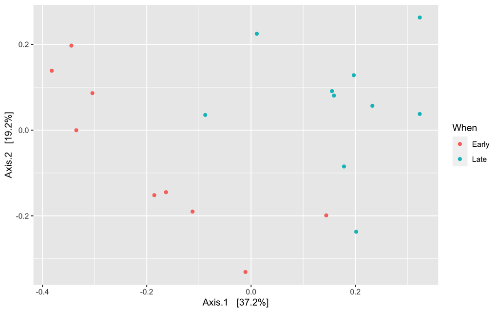

```r
plot_ordination(physeq = phyloseq_rel,
                ordination = ordinate(phyloseq_rel, "MDS", "jaccard"),
                col = "When"
                )
```

### Redundancy analysis (RDA) with Morisita-Horn index

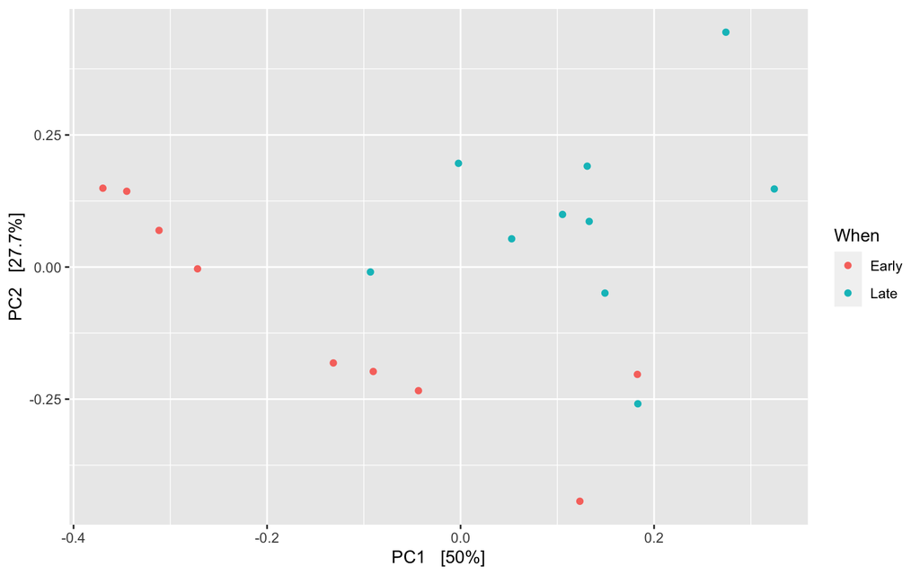

```r
plot_ordination(physeq = phyloseq_rel,
                ordination = ordinate(phyloseq_rel, "RDA", "horn"),
                col = "When"
                )
```

### PCA with Morisita-Horn index

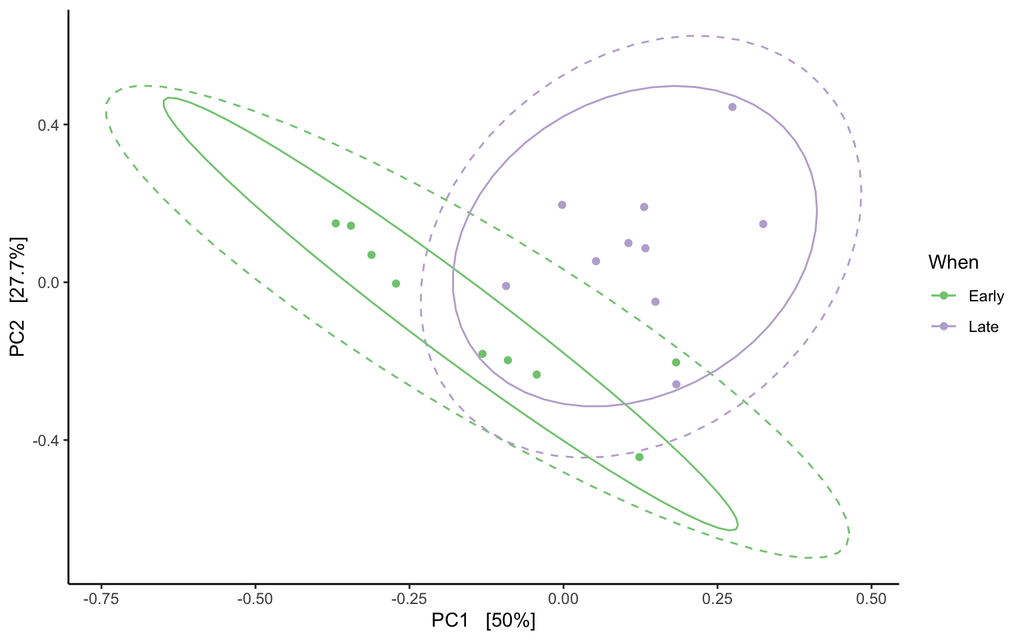

```r
plot_ordination(physeq = phyloseq_rel,
                ordination = ordinate(phyloseq_rel, "RDA", "horn"),
                col = "When"
                ) +
          stat_ellipse(type = "norm", linetype = 2) +
        stat_ellipse(type = "t") +
        theme_classic() +
        scale_color_brewer(type = "qual")
```

# Species richness was different across samples. Was there a effect of sequencing depth?

Calculating total reads

```r
sample_data(phyloseq_rel)$total_reads <- sample_sums(phyloseq_filtered)

sample_data(phyloseq_rel)
```

```
##        Subject Gender Day  When observed chao1 diversity_inverse_simpson
## F3D0         3      F   0 Early       27    27                  6.055101
## F3D1         3      F   1 Early       27    27                  5.473731
## F3D141       3      F 141  Late       20    20                  7.311927
## F3D142       3      F 142  Late       14    14                  6.118230
## F3D143       3      F 143  Late       20    20                  8.458811
## F3D144       3      F 144  Late       18    18                  6.641652
## F3D145       3      F 145  Late       24    24                  6.477691
## F3D146       3      F 146  Late       22    22                  8.536879
## F3D147       3      F 147  Late       27    27                  9.572472
## F3D148       3      F 148  Late       27    27                  7.532499
## F3D149       3      F 149  Late       27    27                  9.309459
## F3D150       3      F 150  Late       21    21                  8.317748
## F3D2         3      F   2 Early       33    33                  6.532057
## F3D3         3      F   3 Early       21    21                  6.827747
## F3D5         3      F   5 Early       24    24                  5.415914
## F3D6         3      F   6 Early       27    27                  7.339601
## F3D7         3      F   7 Early       19    19                  4.996238
## F3D8         3      F   8 Early       27    27                  6.762416
## F3D9         3      F   9 Early       26    26                  6.356050
##        diversity_gini_simpson diversity_shannon diversity_coverage
## F3D0                0.8348500          2.443989                  3
## F3D1                0.8173092          2.339922                  3
## F3D141              0.8632371          2.292807                  3
## F3D142              0.8365540          2.063371                  3
## F3D143              0.8817801          2.453088                  3
## F3D144              0.8494351          2.266895                  3
## F3D145              0.8456240          2.255152                  3
## F3D146              0.8828612          2.444567                  3
## F3D147              0.8955338          2.605667                  4
## F3D148              0.8672419          2.340649                  3
## F3D149              0.8925824          2.552235                  4
## F3D150              0.8797752          2.489153                  3
## F3D2                0.8469089          2.388560                  2
## F3D3                0.8535388          2.306098                  3
## F3D5                0.8153590          2.239871                  2
## F3D6                0.8637528          2.376133                  3
## F3D7                0.7998494          2.051146                  2
## F3D8                0.8521238          2.341600                  3
## F3D9                0.8426696          2.298808                  3
```

[output cut: 85 more lines]

```
## F3D143           0.000000000        2453
## F3D144           0.002453988        3440
## F3D145           0.003316750        5744
## F3D146           0.000000000        3827
## F3D147           0.003460208       12821
## F3D148           0.002792182        9780
## F3D149           0.000000000       10415
## F3D150           0.000000000        4285
## F3D2             0.003353928       16538
## F3D3             0.000000000        5368
## F3D5             0.002628121        3673
## F3D6             0.002871206        6595
## F3D7             0.001594896        4158
## F3D8             0.002819549        4435
## F3D9             0.006946984        5833
```

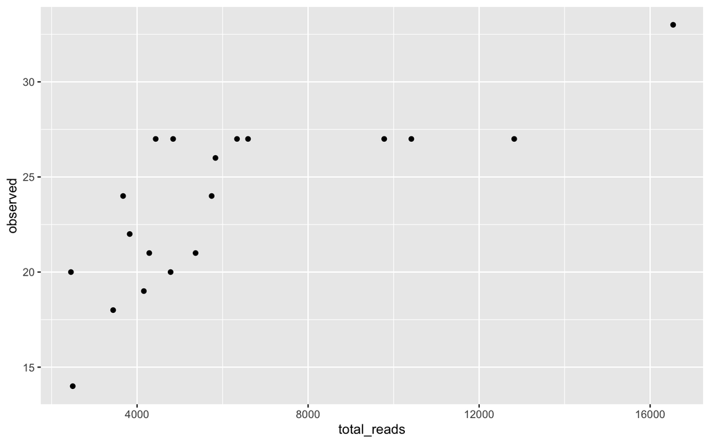

```r
sample_data(phyloseq_rel) %>%
        data.frame() %>%
        ggplot(aes(x = total_reads, y = observed)) +
        geom_point()
```

Color coding with sample data

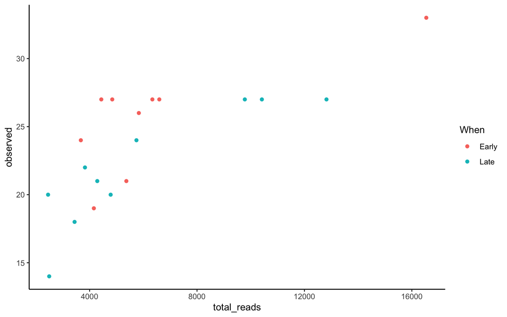

```r
sample_data(phyloseq_rel) %>%
        data.frame() %>%
        ggplot(aes(x = total_reads, y = observed, col = When)) +
        geom_point() +
        theme_classic()
```

It may needs further investigation.

Next lecture will cover how to analyze differences between those to groups *statistically* and how to run *multivariate* analysis!

# Bibliography

[output not shown]